# U-TAD - PEDS: Práctica 14 - Técnicas de aprendizaje no supervisado

Rafael Enríquez-Herrador (rafael.enriquez@live.u-tad.com)

17/02/2016

## Análisis de aceites de oliva (I)

Analizar el fichero `../dat/olive.txt` con dos algoritmos no supervisados. Usar solo las variables numéricas relativas a concentración de sustancias químicas. Dependiendo de los algoritmos elegidos, determinar y razonar (si procede) el número adecuado de clústers o la distancia empleada. Si procede hacer algún tipo de normalización en los datos y cuál. Usar, cuando menos, o *k-medias* o *k-medioides*.

Cargamos las librerías que utilizaremos:

```r
# install.packages("data.table")
library(data.table)
# install.packages("ggplot2")
library(ggplot2)
# install.packages("NbClust")
library(NbClust)
# install.packages("cluster")
library(cluster)
# install.packages("fpc")
library(fpc)
```

Cargamos los datos e inspeccionamos un poco el *dataset*

```r
set.seed(1234)

olive <- read.table(file = "../dat/olive.txt", header = T, sep = "\t")

summary(olive)
```

```
##               Area          Region       palmitic     palmitoleic
##  South-Apulia   :206   North   :151   Min.   : 610   Min.   : 15.00
##  Inland-Sardinia: 65   Sardinia: 98   1st Qu.:1095   1st Qu.: 87.75
##  Calabria       : 56   South   :323   Median :1201   Median :110.00
##  Umbria         : 51                  Mean   :1232   Mean   :126.09
##  East-Liguria   : 50                  3rd Qu.:1360   3rd Qu.:169.25
##  West-Liguria   : 50                  Max.   :1753   Max.   :280.00
##  (Other)        : 94
##     stearic          oleic         linoleic        linolenic
##  Min.   :152.0   Min.   :6300   Min.   : 448.0   Min.   : 0.00
##  1st Qu.:205.0   1st Qu.:7000   1st Qu.: 770.8   1st Qu.:26.00
##  Median :223.0   Median :7302   Median :1030.0   Median :33.00
##  Mean   :228.9   Mean   :7312   Mean   : 980.5   Mean   :31.89
##  3rd Qu.:249.0   3rd Qu.:7680   3rd Qu.:1180.8   3rd Qu.:40.25
##  Max.   :375.0   Max.   :8410   Max.   :1470.0   Max.   :74.00
##
##    arachidic       eicosenoic     Test.Training
##  Min.   :  0.0   Min.   : 1.00   Test    :136
##  1st Qu.: 50.0   1st Qu.: 2.00   Training:436
##  Median : 61.0   Median :17.00
##  Mean   : 58.1   Mean   :16.28
##  3rd Qu.: 70.0   3rd Qu.:28.00
##  Max.   :105.0   Max.   :58.00
##
```

```r
str(olive)
```

```
## 'data.frame':    572 obs. of  11 variables:
##  $ Area         : Factor w/ 9 levels "Calabria","Coast-Sardinia",..: 5 5 5 5 5 5 5 5 5 5 ...
##  $ Region       : Factor w/ 3 levels "North","Sardinia",..: 3 3 3 3 3 3 3 3 3 3 ...
##  $ palmitic     : int  1088 911 966 1051 911 1100 1082 1037 1051 1074 ...
##  $ palmitoleic  : int  73 54 57 67 49 61 60 55 35 70 ...
##  $ stearic      : int  224 246 240 259 268 235 239 213 219 214 ...
##  $ oleic        : int  7709 8113 7952 7771 7924 7728 7745 7944 7978 7728 ...
##  $ linoleic     : int  781 549 619 672 678 734 709 633 605 747 ...
##  $ linolenic    : int  31 31 50 50 51 39 46 26 21 50 ...
##  $ arachidic    : int  61 63 78 80 70 64 83 52 65 79 ...
##  $ eicosenoic   : int  29 29 35 46 44 35 33 30 24 33 ...
##  $ Test.Training: Factor w/ 2 levels "Test","Training": 2 2 2 2 2 2 2 2 2 2 ...
```

De la observación de nuestros datos podemos sacar las siguientes condiciones a *priori*:

- Puede que los datos se puedan organizar adecuadamente en **9** clústeres atendiendo a **Area** o en **3** clústeres atendiendo a **Region** que son las variables categóricas principales que encontramos en el *dataset*.
- Para realizar el *clustering*, deberemos escalar los datos para obtener distancias, puesto que existe una gran diferencia entre los rangos de los datos (véase, por ejemplo **palmitoleic** en comparación con **linoleic**).

Al aplicar el algoritmo del *k-means* y, en orden a decidir el número de clústeres que se ajustan a nuestro *dataset*, el *Total within-cluster sum of squares* es una medida que nos puede aportar mucha información para decidir que número de clústeres es el adecuado, ya que a mayor valor más distintos serán los elementos que pertenecen al mismo clúster.

En primer lugar preparamos los datos para operar con ellos.

```r
# Eliminamos las columnas innecesarias y escalamos los datos.
data <- scale(olive[, -c(1, 2, 11)])
```

Creamos una función que nos permita visualizar para varios números de clústeres seleccionados, aplicando *k-means*, el *Total within-cluster sum of squares*.

```r
wssplot <- function(data, nc = 10, seed = 1234) {
  wss <- (nrow(data) - 1) * sum(apply(data, 2, var))
  for (i in 2:nc){
    set.seed(seed)
    wss[i] <- sum(kmeans(data, centers=i)$withinss)
  }
  plot(1:nc, wss, type="b", xlab="Número de clústeres",
       ylab="Within groups sum of squares")
}
```

Obtenemos la gráfica para 10 clústeres.

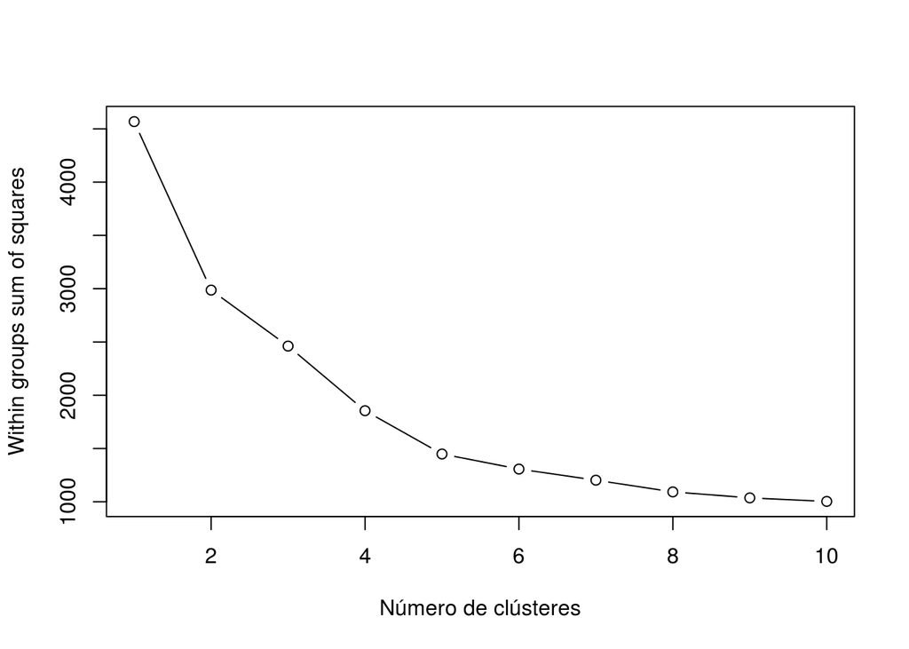

```r
wssplot(data, 10)
```

Se puede observar que tenemos un codo en 5 clústeres, por lo que parece que esta podría ser la agrupación más óptima en relación acierto vs rendimiento para nuestro **dataset**.

Haciendo uso de la función *NbClust* del paquete **NbClust**, intentamos determinar el mejor número de clústeres estudiando la distancia Euclídea.

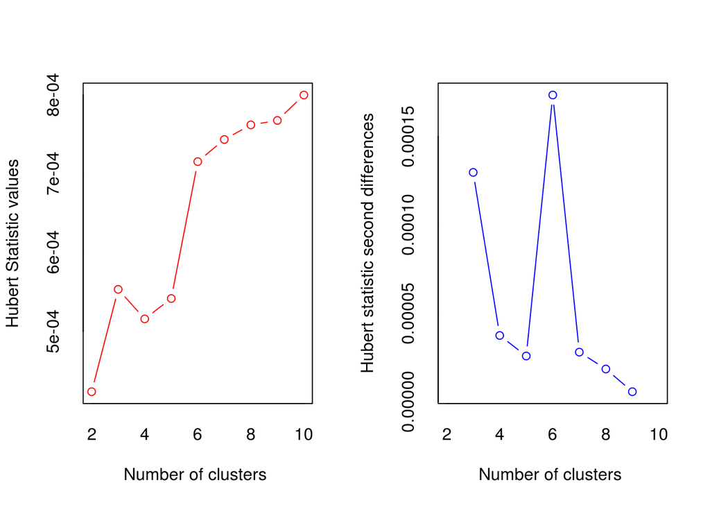

```
## *** : The Hubert index is a graphical method of determining the number of clusters.
##                 In the plot of Hubert index, we seek a significant knee that corresponds to a
##                 significant increase of the value of the measure i.e the significant peak in Hubert
##                 index second differences plot.
##
```

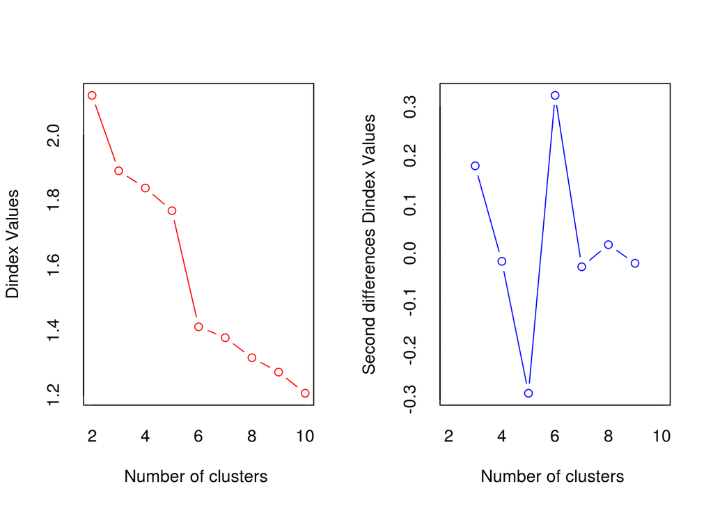

```
## *** : The D index is a graphical method of determining the number of clusters.
##                 In the plot of D index, we seek a significant knee (the significant peak in Dindex
##                 second differences plot) that corresponds to a significant increase of the value of
##                 the measure.
##
## * Among all indices:
## * 6 proposed 2 as the best number of clusters
## * 5 proposed 3 as the best number of clusters
## * 9 proposed 6 as the best number of clusters
## * 1 proposed 9 as the best number of clusters
## * 2 proposed 10 as the best number of clusters
##
##                    ***** Conclusion *****
##
## * According to the majority rule, the best number of clusters is  6
##
##
```

```r
nc <- NbClust(data, min.nc = 2, max.nc = 10,
              distance = "euclidean", method = "kmeans")
```

```r
table(nc$Best.nc[1,])
```

```
##
##  0  1  2  3  6  9 10
##  2  1  6  5  9  1  2
```

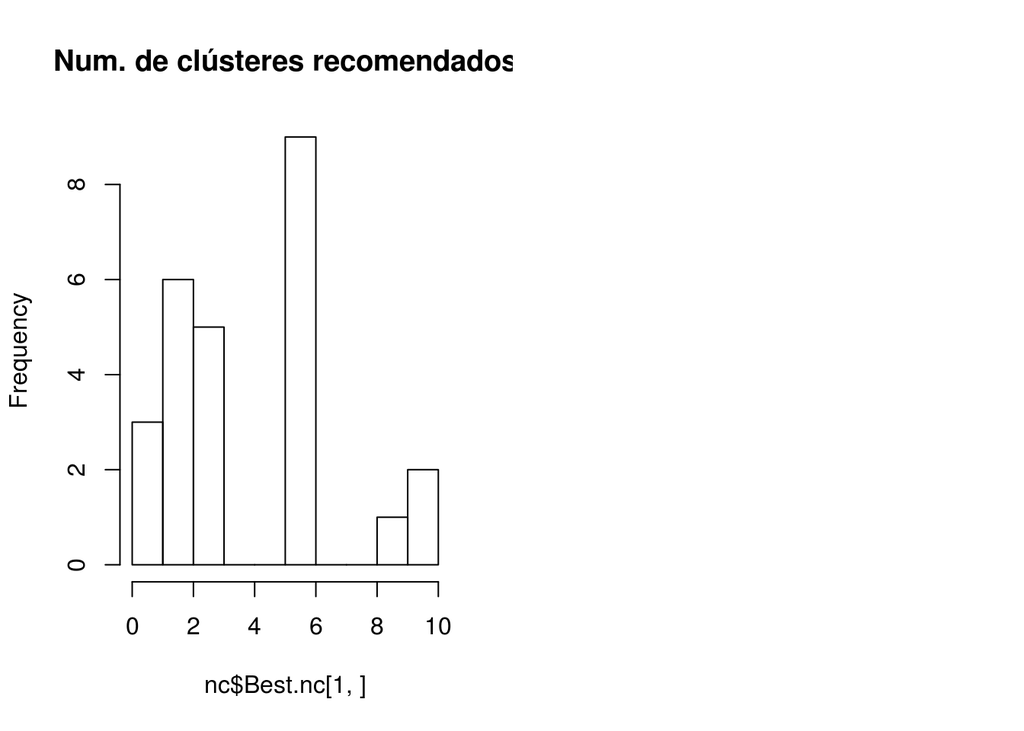

```r
hist(nc$Best.nc[1,], breaks = max(na.omit(nc$Best.nc[1,])),
     main = "Num. de clústeres recomendados")
```

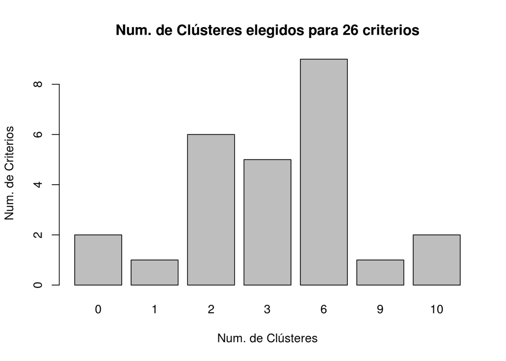

```r
barplot(table(nc$Best.n[1,]),
        xlab="Num. de Clústeres", ylab="Num. de Criterios",
        main="Num. de Clústeres elegidos para 26 criterios")
```

```r
set.seed(1234)
fit.km <- kmeans(data, 6, nstart = 25)
fit.km$size
```

```
## [1]  80 103  86  39 204  60
```

```r
fit.km$centers
```

```
##     palmitic palmitoleic     stearic      oleic   linoleic   linolenic
## 1  0.4673034 -0.06228108  0.83745189 -0.1184316 -0.5296680  1.00911355
## 2 -0.6972270 -0.56163657 -0.06794005 -0.0704349  0.8067563 -0.33649024
## 3 -0.7492791 -1.08452813 -0.45866884  1.3990859 -1.4447005 -0.05054893
## 4 -1.1344179 -1.19508888  1.09155110  1.0703385 -1.0928721  1.02092700
## 5  0.9877579  1.11839654 -0.52261951 -0.9943028  0.7675852  0.21009305
## 6 -0.9732036 -0.42406594  0.72485134  0.9583751 -0.5073931 -2.07330862
##     arachidic eicosenoic
## 1  0.53742459  0.9359338
## 2  0.72579643 -1.0209653
## 3 -0.28524182 -0.9381115
## 4  0.61475125  1.4766043
## 5  0.06987451  0.5588530
## 6 -2.19083167 -1.0105212
```

```r
aggregate(olive[, 3:10], by=list(cluster=fit.km$cluster), mean)
```

```
##   cluster palmitic palmitoleic  stearic    oleic  linoleic linolenic
## 1       1 1310.525   122.82500 259.6375 7263.688  851.9250  44.97500
## 2       2 1114.194    96.61165 226.3689 7283.165 1176.4078  27.52427
## 3       3 1105.419    69.16279 212.0116 7879.512  629.7558  31.23256
## 4       4 1040.487    63.35897 268.9744 7746.103  715.1795  45.12821
## 5       5 1398.270   184.80392 209.6618 6908.250 1166.8971  34.61275
## 6       6 1067.667   103.83333 255.5000 7700.667  857.3333   5.00000
##   arachidic eicosenoic
## 1 69.937500  29.462500
## 2 74.087379   1.902913
## 3 51.813953   3.069767
## 4 71.641026  37.076923
## 5 59.637255  24.151961
## 6  9.833333   2.050000
```

Hacemos lo mismo para *k-medioids*, utilizando la funcion **pam** del paquete *cluster* y obtenemos el mejor número de clústeres a utilizar (entre 2 y 10) mediante la funcion **pamk** del paquete *fpc*.

```r
pamk.best <- pamk(data, krange = 2:10)
pamk.best$nc
```

```
## [1] 5
```

Observamos que para *k-medioids* el mejor número de clústeres en este caso es 5, muy similar al obtenido para *k-means*.

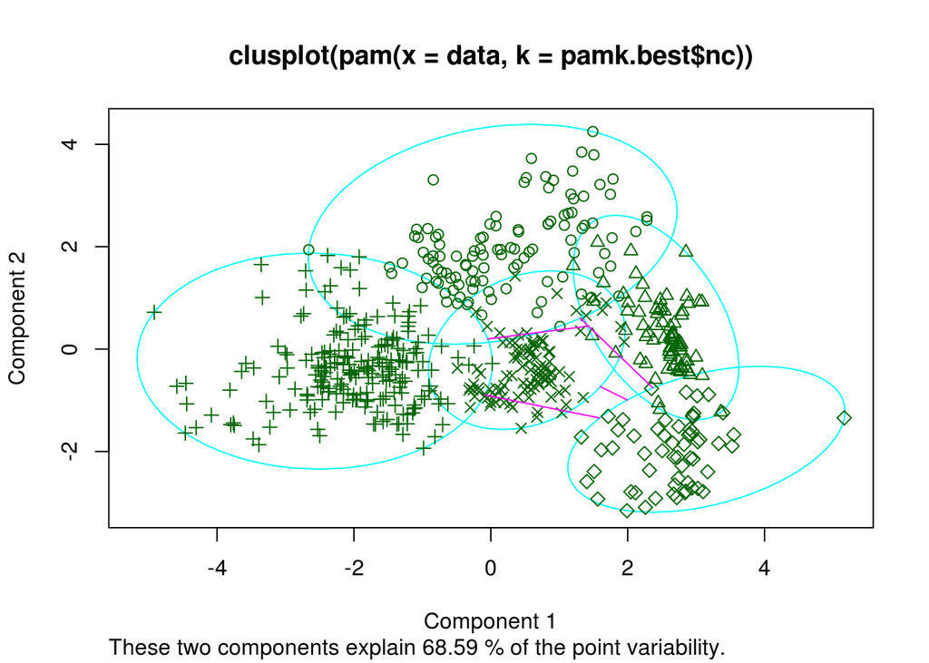

[figure not shown]

```r
fit.pam <- pam(data, pamk.best$nc)
plot(pam(data, pamk.best$nc))
```

```r
aggregate(olive[, 3:10], by=list(cluster=fit.pam$clustering), mean)
```

```
##   cluster palmitic palmitoleic  stearic    oleic  linoleic linolenic
## 1       1 1205.685    97.93694 263.3153 7470.378  783.5766 45.180180
## 2       2 1096.468    64.83117 205.6753 7913.948  617.9091 31.116883
## 3       3 1397.847   183.25000 212.5000 6912.213 1158.0833 34.972222
## 4       4 1115.064    96.70642 227.8532 7307.119 1149.6330 27.385321
## 5       5 1064.746   104.06780 256.1017 7698.644  861.8644  4.915254
##   arachidic eicosenoic
## 1 70.000000  30.324324
## 2 48.103896   3.727273
## 3 60.634259  24.680556
## 4 74.321101   1.899083
## 5  9.491525   2.067797
```

Como conslusión del ejercicio, resulta curioso resaltar que el número adecuado de clústeres recomendados se encuentre entre cercano a la media del número de niveles presentes en las variables categóricas de nuestro *dataset*: 9 niveles para **Area** y 3 niveles para **Region**.